# Human Activity Recognition Analysis

```r
library(dplyr)
library(caret)
library(corrgram)
library(randomForest)
```

## Background

Using devices such as Jawbone Up, Nike FuelBand, and Fitbit it is now possible to collect a large amount of data about personal activity relatively inexpensively. These type of devices are part of the quantified self movement - a group of enthusiasts who take measurements about themselves regularly to improve their health, to find patterns in their behavior, or because they are tech geeks. One thing that people regularly do is quantify how much of a particular activity they do, but they rarely quantify how well they do it. In this project, your goal will be to use data from accelerometers on the belt, forearm, arm, and dumbell of 6 participants. They were asked to perform barbell lifts correctly and incorrectly in 5 different ways. More information is available from the website here: http://groupware.les.inf.puc-rio.br/har (see the section on the Weight Lifting Exercise Dataset).

1.Exactly according to the specification (Class A)

2.Throwing the elbows to the front (Class B)

3.Lifting the dumbbell only halfway (Class C)

4.Lowering the dumbbell only halfway (Class D)

5.Throwing the hips to the front (Class E)

The goal of your project is to predict the manner in which they did the exercise. This is the “classe” variable in the training set. You may use any of the other variables to predict with.

## Executive Summary

Initially I planned to several models and compare them, and perhaps combine them to get better predictions however, after running my analysis using random forests I was surprised by the accuracy of the model and decided not to pursue any further algorithms.

## Data Discovery

### Loading the Data

Load Data Sets (Training and Testing)

```r
# Load data files into R
 training_raw <- read.csv("pml-training.csv", header = TRUE, na.strings=c("NA", "#DIV/0!"))
 test_raw  <- read.csv('pml-testing.csv',header = TRUE, na.strings=c("NA", "#DIV/0!"))
```

### Preprocessing the Data

My initial review of the data showed many Issues with the data.

1.Many columns with No data (NA) values

2.Many columns with a single value or very low frequencies

3.Columns with data that was not relevant to the analysis like record number and timestamps.

The issues highlighted above can be a burden to many machine learning procedures. I resolved to remove them from the analytical data sets by:

1.Removing the columns that are not needed for analysis like time stamps,names and row numbers.

2.Removing the columns that have that Zero and Near Zero-Variance Predictors.

3.Impune the missing values to those columns that are left that have missing values.

4.Center and Scale the data.

```r
# set the seed to ensure repatable answers
   set.seed(12121963)
# Removing the columns that are not needed for analysis like time stamps,names and row numbers.
   training <- training_raw[,-c(1:8)]
# Removing the columns that have  that Zero and Near Zero-Variance Predictors.
   NZV_columns <- nearZeroVar(training, saveMetrics = TRUE)
   training <- training[, NZV_columns$nzv == FALSE]
# Impune the missing values to those columns that are left that have missing values
# Impune the columns that will be impuned,centered and scaled
   numeric_columns <- which(lapply(training,class) %in% c('numeric','intiger'))
# Get the impute model
   impute_mdl <- preProcess(training[,numeric_columns], method=c('knnImpute'))
# Assign the impuned data values
   train_imp <- predict(impute_mdl,training[,numeric_columns])
# Add back the non-numeric columns
   training <- cbind(training$classe, train_imp)
   colnames(training)[1] <- "classe"
# capture final results
   train_cols <- dim(training_raw)[2]
   procd_cols <- dim(training)[2]
```

The original training data set had **160** variables before, after the initial pre-processing steps the zero-variance predictors, **86** .I felt that the number was still high so I decided to see if the data had columns that were highly correlated and candidates for further reduction.To answer this question I did the following;

1. Carried out some Correantion Analyis

```r
#create a correaltion matrix of the cleaned data
 training_corr <- cor(train_imp)
 high_corr_row_count <- nrow(which(training_corr > 0.7, arr.ind=T))
 pct_cnt <- round((high_corr_row_count/((dim(training_corr)[1])^2))*100,3)
```

## Data Modeling

The Random Forests algorithm is one of the best among classification algorithms - able to classify large amounts of data with accuracy. I decided to use it to predict what classes.

### Train the Model

```r
  factor(training$classe)
```

```r
# split into traing and validation sets
   train_split <- createDataPartition(training$classe, p = 0.80, list = FALSE)
   train_learn <- training[train_split, ]
   train_valid <- training[-train_split, ]
# Train the model with the learning data set
   rf_mdl <- train(classe ~ ., method="rf", data=train_learn)
```

#### Training the Model Analyis

```r
# Summary of the Model
   print(rf_mdl)
```

```
## Random Forest
##
## 15699 samples
##    85 predictor
##     5 classes: 'A', 'B', 'C', 'D', 'E'
##
## No pre-processing
## Resampling: Bootstrapped (25 reps)
## Summary of sample sizes: 15699, 15699, 15699, 15699, 15699, 15699, ...
## Resampling results across tuning parameters:
##
##   mtry  Accuracy   Kappa      Accuracy SD  Kappa SD
##    2    0.9292898  0.9104873  0.004142646  0.005246949
##   43    0.9817471  0.9769030  0.002038167  0.002579036
##   85    0.9751079  0.9685058  0.004022980  0.005090883
##
## Accuracy was used to select the optimal model using  the largest value.
## The final value used for the model was mtry = 43.
```

Final Random Forest Model output

```r
 print(rf_mdl$finalModel)
```

```
##
## Call:
##  randomForest(x = x, y = y, mtry = param$mtry)
##                Type of random forest: classification
##                      Number of trees: 500
## No. of variables tried at each split: 43
##
##         OOB estimate of  error rate: 1%
## Confusion matrix:
##      A    B    C    D    E class.error
## A 4454    7    2    0    1 0.002240143
## B   26 2992   13    0    7 0.015141540
## C    0   22 2684   28    4 0.019722425
## D    0    2   18 2548    5 0.009716284
## E    0    6   12    4 2864 0.007623008
```

### Validate the Model

```r
# Validate the model with the validation data set
   rf_valid <- predict(rf_mdl,train_valid)
# Confusion matrix for validation step
  confusionMatrix(rf_valid, train_valid$classe)
```

```
## Confusion Matrix and Statistics
##
##           Reference
## Prediction    A    B    C    D    E
##          A 1112    6    0    0    1
##          B    3  748    8    0    0
##          C    0    4  672    0    1
##          D    1    0    3  641    2
##          E    0    1    1    2  717
##
## Overall Statistics
##
##                Accuracy : 0.9916
##                  95% CI : (0.9882, 0.9942)
##     No Information Rate : 0.2845
##     P-Value [Acc > NIR] : < 2.2e-16
##
##                   Kappa : 0.9894
##  Mcnemar's Test P-Value : NA
##
## Statistics by Class:
##
##                      Class: A Class: B Class: C Class: D Class: E
## Sensitivity            0.9964   0.9855   0.9825   0.9969   0.9945
## Specificity            0.9975   0.9965   0.9985   0.9982   0.9988
## Pos Pred Value         0.9937   0.9855   0.9926   0.9907   0.9945
## Neg Pred Value         0.9986   0.9965   0.9963   0.9994   0.9988
## Prevalence             0.2845   0.1935   0.1744   0.1639   0.1838
## Detection Rate         0.2835   0.1907   0.1713   0.1634   0.1828
## Detection Prevalence   0.2852   0.1935   0.1726   0.1649   0.1838
## Balanced Accuracy      0.9970   0.9910   0.9905   0.9975   0.9966
```

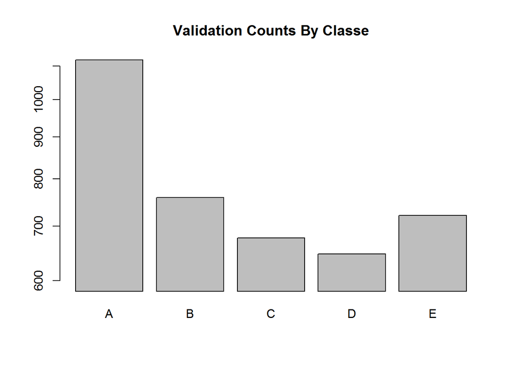

```r
# Plot the model
   plot(rf_valid,log="y",main="Validation Counts By Classe")
```

### Sample Error Analyis

Sampling Errors - The sampling error is the difference between a sample statistic used to estimate a population parameter and the actual but unknown value of the parameter. The sampling error calculations was carried out in two groups. First was the error for the learning step and the other for the validation step.

Since I used the Random forest classifier; there is was no need to perform Sample Error Analysis. In random forests, there is no need for cross-validation or a separate test set to get an unbiased estimate of the test set error. It is estimated internally, during the run because each tree is constructed using a different bootstrap sample from the original data. The Sample Error rate for the method is called the Out of the Box error which was for the training model was 1.01%. The diagram bellow shows how the Error went from about 15% to near Zero after the first 100 Trees were built.

### Random Forest Model Sampling Error Graph(s)

##### Sampling Error Based on the Number of Trees

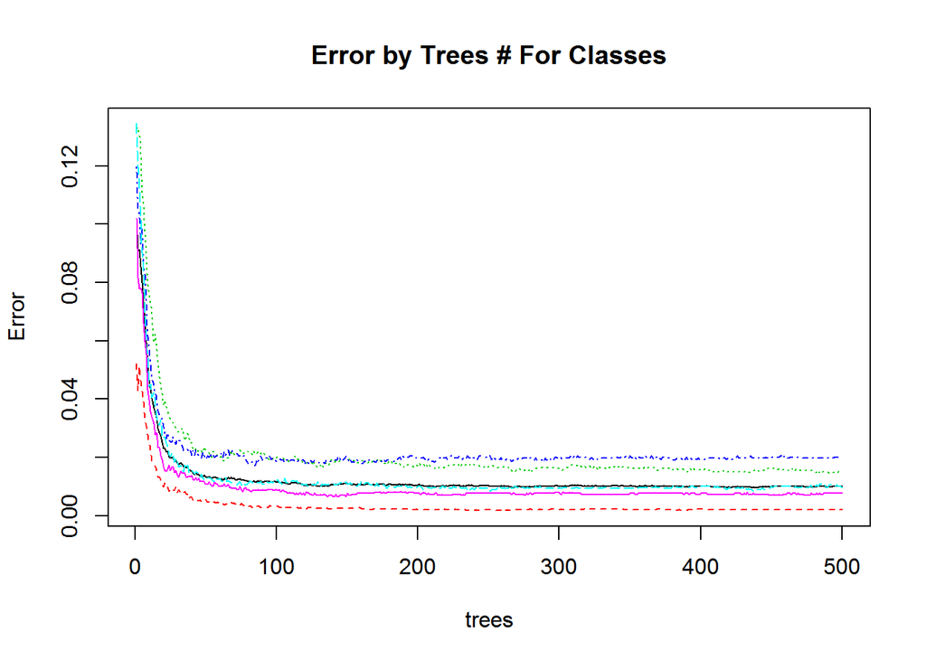

```r
 # Plot the random forest Error over muliple Tree Iterations
    plot(rf_mdl$finalModel,main="Error by Trees # For Classes")
```

##### Sampling Error Based on the Random Selected Predictors

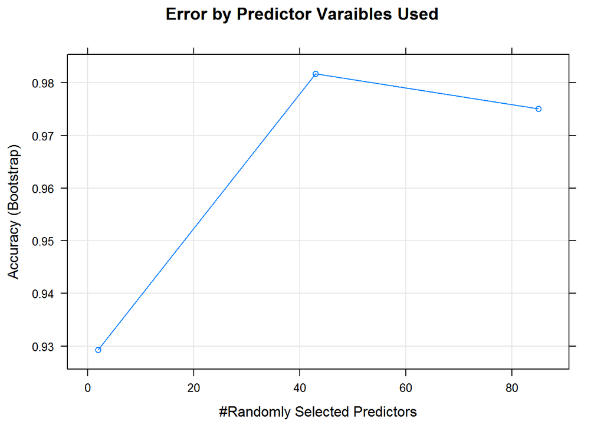

```r
# Plot the random forest Error based on the number of Randomly selected Variables.
   plot(rf_mdl,log="y", main="Error by Predictor Varaibles Used")
```

However, I did carry out some rudimentary Error Analysis suing the description provided above.

#### Sample errors (in sample)

```r
# Predict the classe using the model crerated on the original learing data
   rf_pred_learn <- predict(rf_mdl,train_learn)
# calculate the Sampling error for the training step
   smp_err_in <- rf_pred_learn == train_learn$classe
   summary(smp_err_in)
```

```
##    Mode    TRUE    NA's
## logical   15699       0
```

```r
   in_err_pct <- (sum(smp_err_in == FALSE)/sum(smp_err_in == TRUE))*100
```

The in-smaple Sampling error was **0** %.

#### Sample errors (in cross-validation)

```r
# calculate the Sampling error for the cross validation step
  smp_err_out <- rf_valid == train_valid$classe
  summary(smp_err_out)
```

```
##    Mode   FALSE    TRUE    NA's
## logical      33    3890       0
```

```r
  out_err_pct <- (sum(smp_err_out == FALSE)/sum(smp_err_out == TRUE))*100
```

## Analysis Results

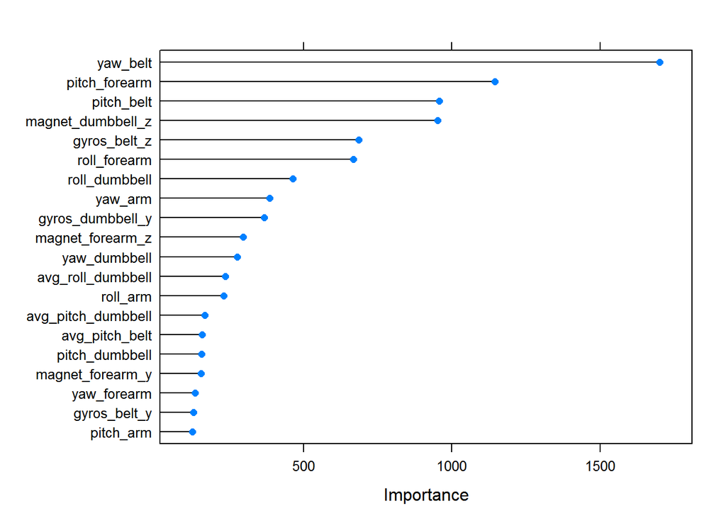

```r
 # what are the most important variables from the model
   var_importance <- varImp(rf_mdl, scale=FALSE)
   plot(var_importance, top=20)
```

## Testing the Model

After creating and validating the Random Forest Model, I tested the model with a test file by predcting what class the subjects would bellong.

```r
# remove from test data set any columns not used to build the Random Forest Model
  test <- test_raw[, colnames(train_imp)]
# Repalce NAs with Zeros
  test[is.na(test)] <- 0
# Apply the same pre-processing process that was used in the traing and validation steps
  test_sc <- preProcess(test, method = c("center", "scale","knnImpute"))
  test_clean <- predict(test_sc, test)
# Make the predictions
  rf_test <- predict(rf_mdl,newdata=test_clean)
# Write the result in the working Directory
  filename <- getwd()
# Function to purse and break down the results into individual files.
      pml_write_files = function(x){
         n = length(x)
         for(i in 1:n){
            filename = paste0("problem_id_",i,".txt")
            write.table(x[i],file=filename,quote=FALSE,row.names=FALSE,col.names=FALSE)
         }
      }
# Process test results
pml_write_files(rf_test)
```

The predictions for the test data are listed Bellow

### Test Result String

```r
 rf_test# Test Reuslts
```

```
##  [1] E A E D C E E E A A B E D A E E E B E D
## Levels: A B C D E
```

### Test Result Graph

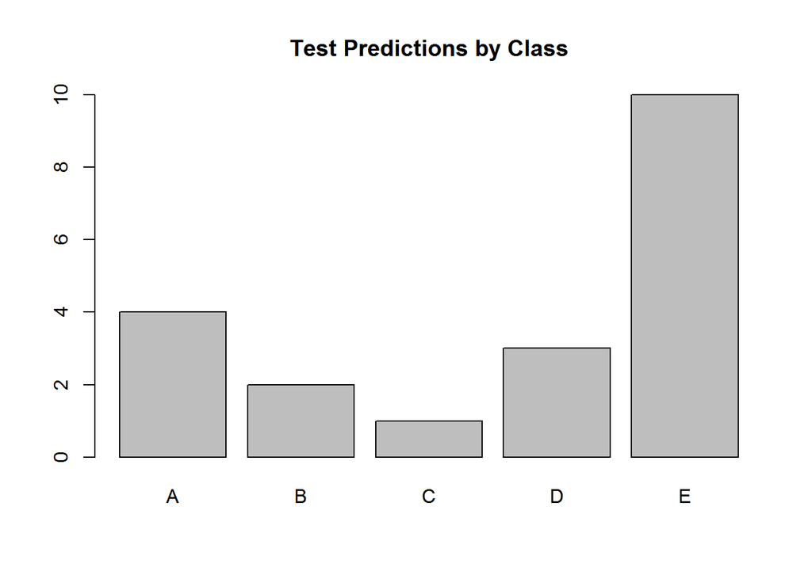

```r
 plot(rf_test,main="Test Predictions by Class")
```

## Appendix

### A.1 - Zero and Near Zero-Variance Predictors eliminated Analyis output

```r
filter(NZV_columns,nzv==TRUE)
```

```
##    freqRatio percentUnique zeroVar  nzv
## 1    0.00000    0.00000000    TRUE TRUE
## 2    0.00000    0.00000000    TRUE TRUE
## 3    0.00000    0.00509632    TRUE TRUE
## 4   77.00000    1.68178575   FALSE TRUE
## 5   77.00000    1.68178575   FALSE TRUE
## 6   77.00000    1.68178575   FALSE TRUE
## 7   77.00000    1.68178575   FALSE TRUE
## 8   77.00000    1.68178575   FALSE TRUE
## 9   77.00000    1.68178575   FALSE TRUE
## 10  77.00000    1.68178575   FALSE TRUE
## 11  80.00000    1.66649679   FALSE TRUE
## 12  80.00000    1.66649679   FALSE TRUE
## 13  25.66667    1.47793293   FALSE TRUE
## 14  19.25000    1.41677709   FALSE TRUE
```

[output cut: 21 more lines]

### A.2 - Possible Correlated columns after first pre-processing steps.

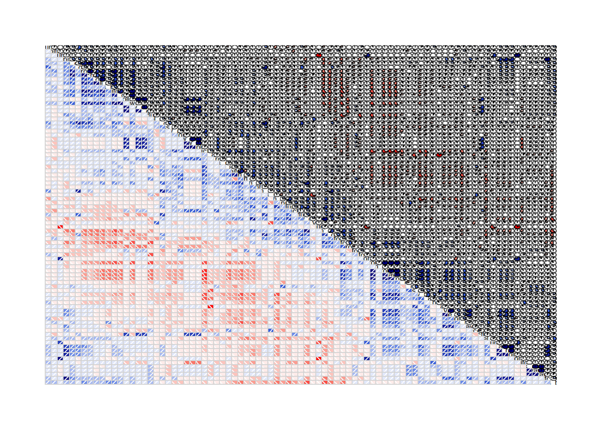

```r
corrgram(training_corr,order=TRUE,lower.panel=panel.shade,upper.panel=panel.pie,text.panel=panel.txt)
```

### A.3 Predictor Variable Importance.

[figure not shown]

```r
 plot(var_importance)
```